# Lecture Notes for Statistics for Biology FS2020

### The grammar of ggplot

With ggplot2, you begin a plot with the function ggplot(). ggplot() creates a coordinate system that you can add layers to. The first argument of ggplot() is the dataset to use in the graph. So ggplot(data = mpg) creates an empty graph, but it’s not very interesting so I’m not going to show it here.

You complete your graph by adding one or more layers to ggplot(). The function geom_point() adds a layer of points to your plot, which creates a scatterplot. ggplot2 comes with many geom functions that each add a different type of layer to a plot. You’ll learn a whole bunch of them throughout this chapter.

Each geom function in ggplot2 takes a mapping argument. This defines how variables in your dataset are mapped to visual properties. The mapping argument is always paired with aes(), and the x and y arguments of aes() specify which variables to map to the x and y axes. ggplot2 looks for the mapped variables in the data argument, in this case, mpg.

Next, we use a different theme beacuse this gray background in the standard design is ugly.

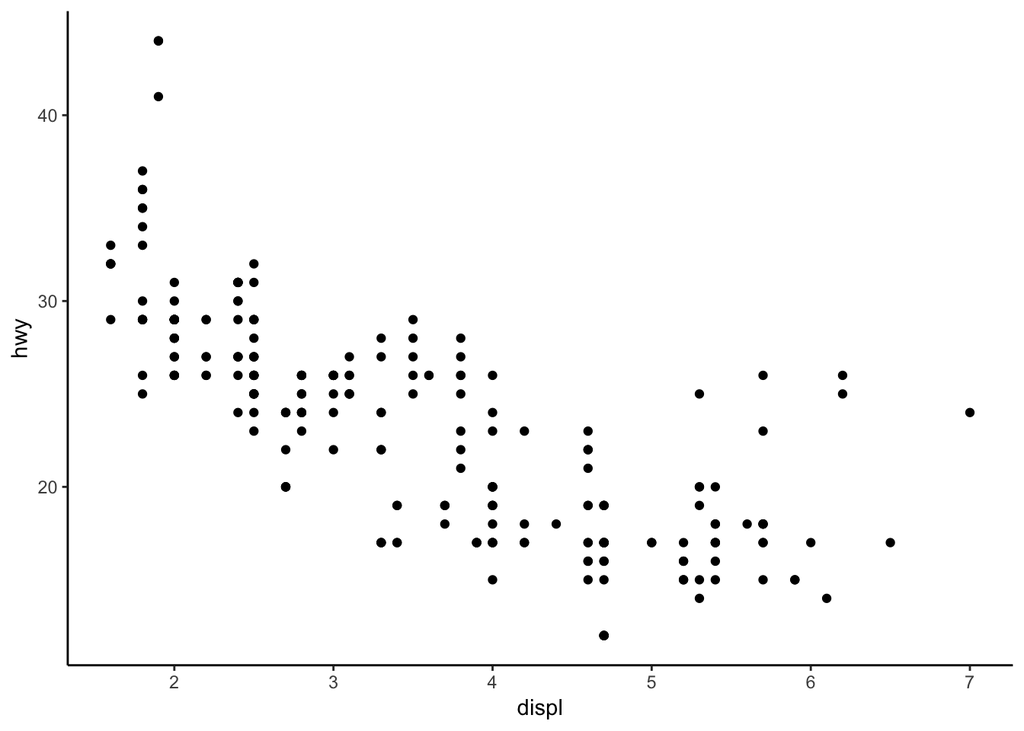

```r
ggplot(data = mpg) +
  geom_point(mapping = aes(x = displ, y = hwy)) +
  theme_classic()
```

The general grammar of ggplot is

ggplot(data = <DATA>) +

<GEOM_FUNCTION>(mapping = aes(<MAPPINGS>))

We will explain each part step by step in examples. The DATA argument should be quite clear: here you specify the dataframe (we will learn more about that alter) that you want to work with.

The second part, GEOM_FUNCTION, specifies what kind of plot you want. for instance, geom_point gives you a classic scatter plot, whereas geom_smooth would give you a smooth line theat best resembles the cloud of points (more on that later):

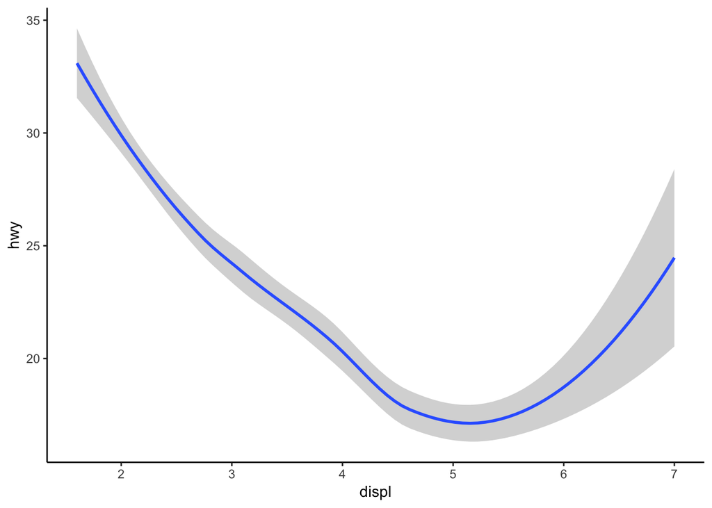

```r
ggplot(data = mpg) +
  geom_smooth(mapping = aes(x = displ, y = hwy)) +
  theme_classic()
```

Of course, we can put points and a smooth line on the same plot:

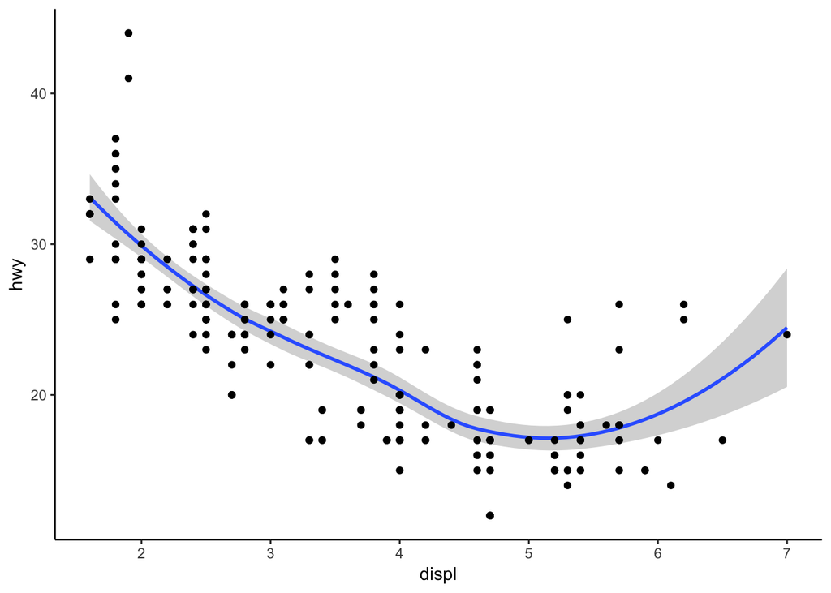

```r
ggplot(data = mpg) +
  geom_smooth(mapping = aes(x = displ, y = hwy)) +
  geom_point(mapping = aes(x = displ, y = hwy)) +
  theme_classic()
```

You may wonder how the smooth line is determined. We will come back to this later in the chapter on linear regression. For now, we just mention that we can modify the method used for the plot, e.g., to get a linear regression line:

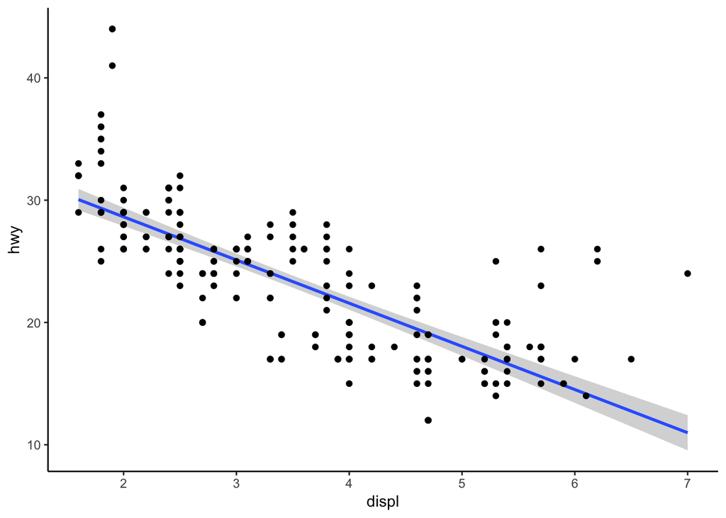

```r
ggplot(data = mpg) +
  geom_smooth(mapping = aes(x = displ, y = hwy),method='lm') +
  geom_point(mapping = aes(x = displ, y = hwy)) +
  theme_classic()
```

Finally, MAPPING specifies which variables hould be plotted. We ussually specify this with an aesthetics mapping of the form mapping = aes(x = …, y =…) to deterimne the variables that give us the x- and y-coordinates. We can however also change the aesthetics of our plot in various way, for instance by giving data points different colors that indicate the value of a third variable:

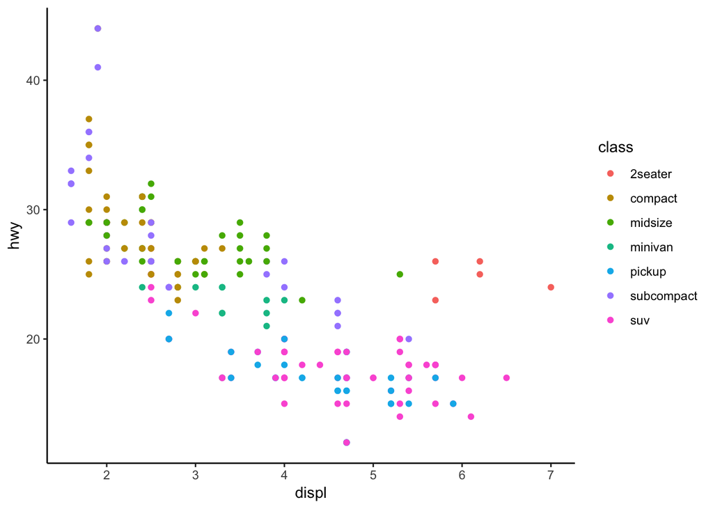

```r
ggplot(data = mpg) +
  geom_point(mapping = aes(x = displ, y = hwy,color = class)) +
  theme_classic()
```

Another important option is to set a clor manually:

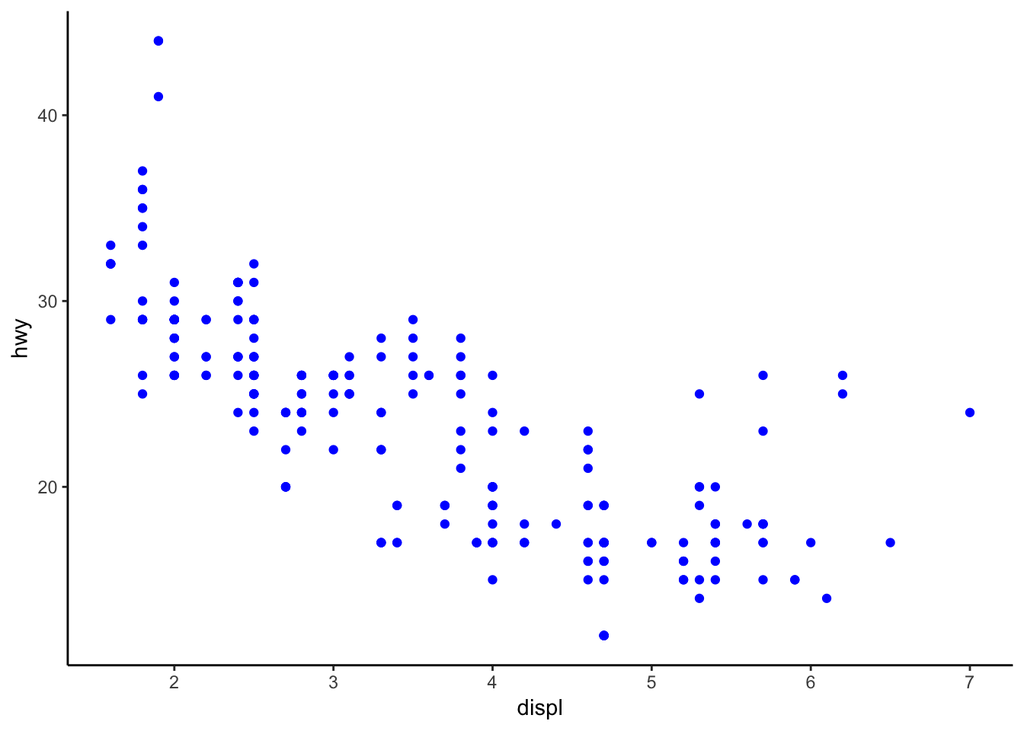

```r
ggplot(data = mpg) +
  geom_point(mapping = aes(x = displ, y = hwy), color = "blue") +
  theme_classic()
```

As a final remark, you can also create a plot, store it in a variable and then explore themes after that:

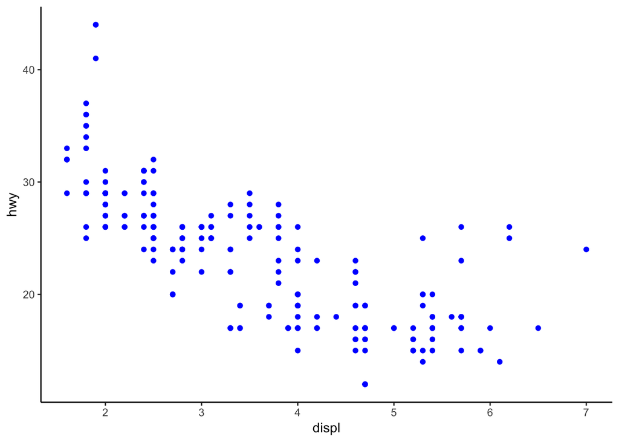

```r
p = ggplot(data = mpg) +
  geom_point(mapping = aes(x = displ, y = hwy), color = "blue")

p+theme_classic()
```

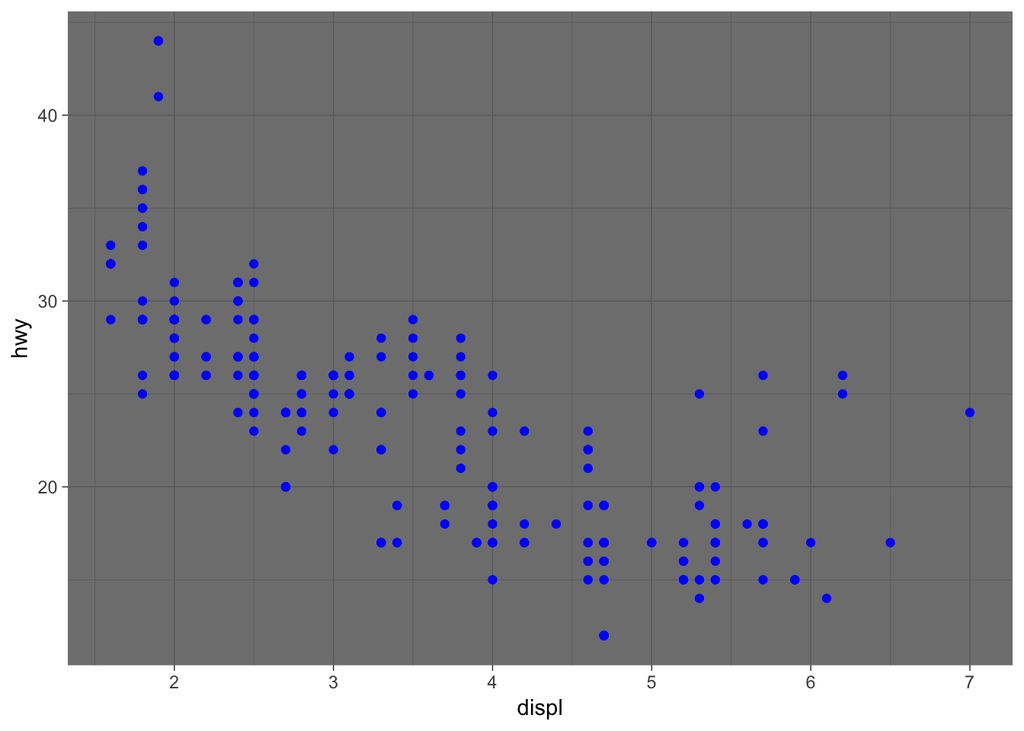

```r
p+theme_dark()
```

# Descriptive Statistics

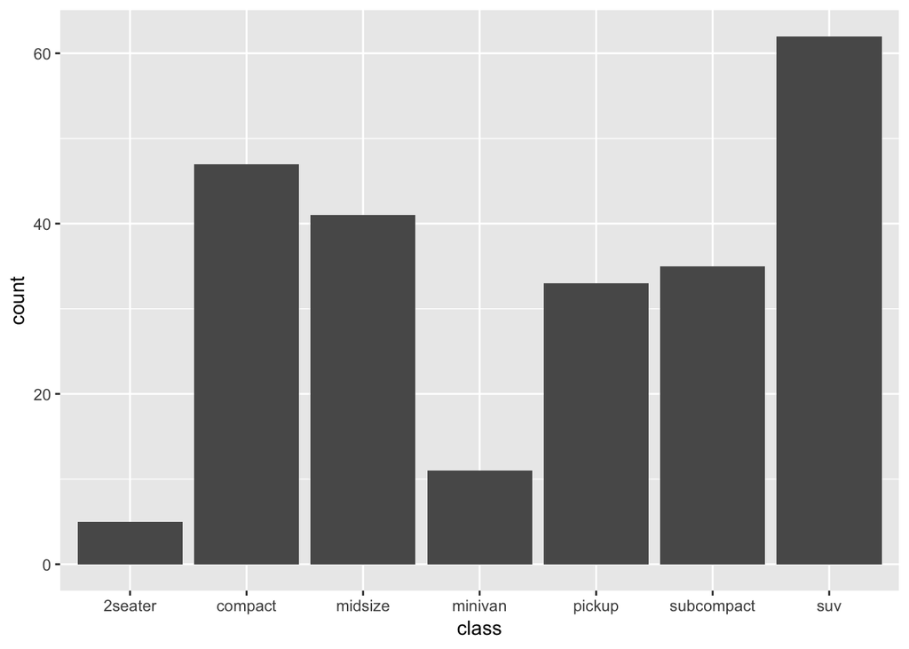

```r
ggplot(data = mpg) +
  geom_bar(mapping = aes(x = class))
```

We can make stacked graphs using the argument $fill$ and a discrete variable such as number of cylinders

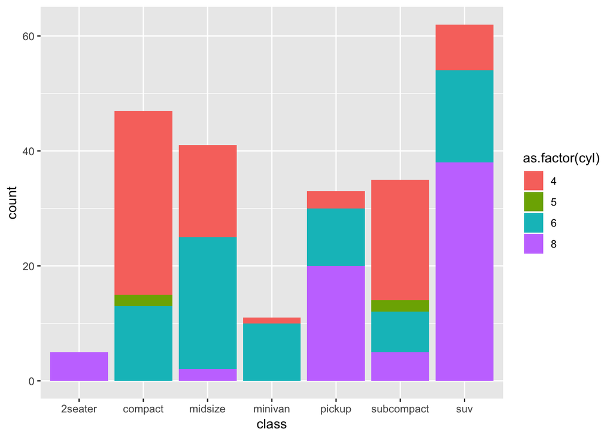

```r
ggplot(data = mpg) +
  geom_bar(mapping = aes(x = class, fill = as.factor(cyl)))
```

If we want to show the distribution of a continous variable for each class, we can do boxplots, e.g., showing the mileage of each class

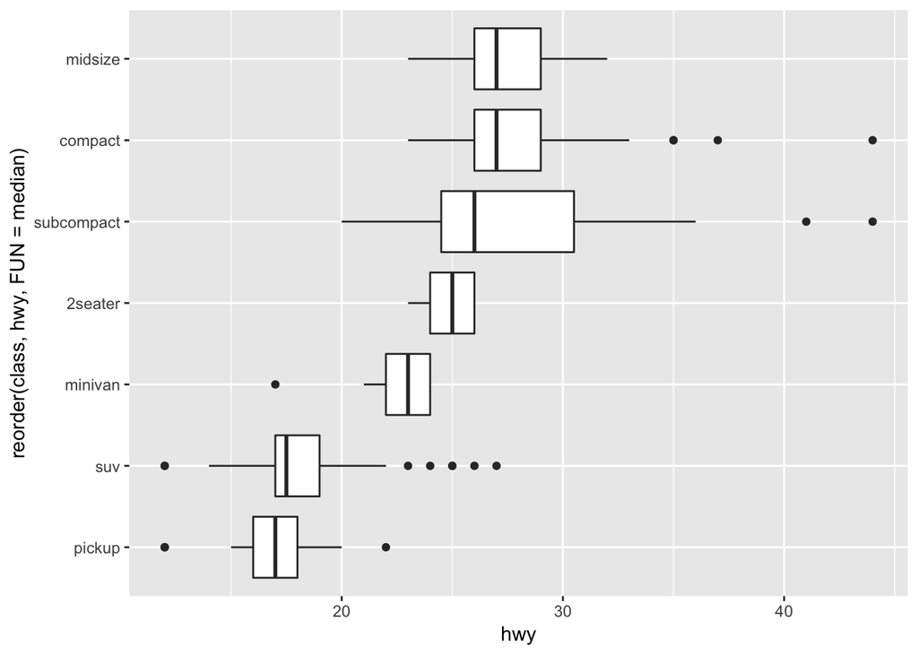

```r
ggplot(data = mpg) +
geom_boxplot(mapping = aes(x = reorder(class, hwy, FUN = median), y = hwy)) +
coord_flip()
```

Another way of summarizing data is by showing several statistics using whisker plots. A simple solution is using the stat_summary function. In the example below the dots show the median, and the whiskers extend to the minium and maximum in each category (class).

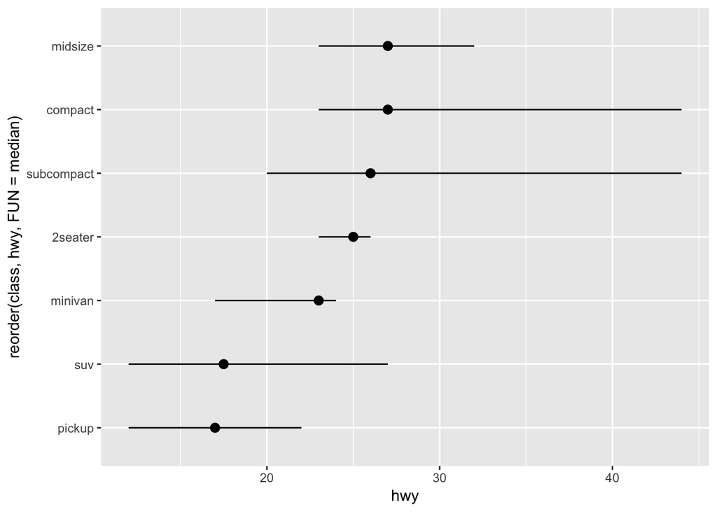

```r
ggplot(data = mpg) +
  stat_summary(
    mapping = aes(x = reorder(class, hwy, FUN = median), y = hwy),
    fun.ymin = min,
    fun.ymax = max,
    fun.y = median
  ) +
  coord_flip()
```

If we want to show confidnece intervalls (or any otehr quantity), a clean way to do this is to simply create a data set containing this information and then use it to plot the quantitites.

```r
mpgSE <- summarySE(mpg, measurevar="hwy", groupvars=c("class"))

mpgSE
```

```
##        class  N      hwy       sd        se        ci
## 1    2seater  5 24.80000 1.303840 0.5830952 1.6189318
## 2    compact 47 28.29787 3.781620 0.5516059 1.1103251
## 3    midsize 41 27.29268 2.135930 0.3335762 0.6741826
## 4    minivan 11 22.36364 2.062655 0.6219139 1.3857105
## 5     pickup 33 16.87879 2.274280 0.3959013 0.8064245
## 6 subcompact 35 28.14286 5.375012 0.9085429 1.8463813
## 7        suv 62 18.12903 2.977973 0.3782030 0.7562636
```

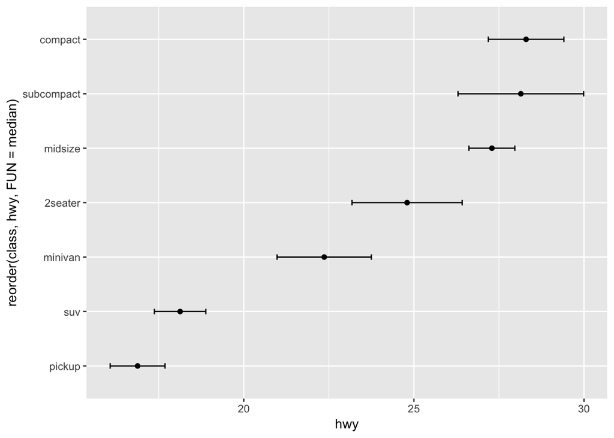

```r
ggplot(mpgSE, aes(x = reorder(class, hwy, FUN = median), y = hwy)) +
    geom_errorbar(aes(ymin=hwy-ci, ymax=hwy+ci), width=.1) +
    geom_point() +
    coord_flip()
```